## The Model

### Model Overview

This model consists of 4 compartments and can capture some of the basic dynamics of viral infections. In this model, we track the following entities by assigning each to a compartment:

- **U** - uninfected cells
- **I** - infected cells
- **V** - (free) virus
- **C** - drug levels

In addition to specifying the *compartments* of a model, we need to specify the processes governing the model dynamics. For our system, we specify the following processes/flows:

- Uninfected cells are produced at some rate *n* and naturally die at some rate *d<sub>U</sub>*.
- Virus infects cells at rate *b*, with unit conversion factor *g*.
- Infected cells produce new virus at rate *p* and die at rate *d<sub>I</sub>*.
- Free virus is removed at rate *d<sub>V</sub>* or goes on to infect further uninfected cells.
- Once treatment has started (*t>txstart*), drug kinetics is modeled as growing linearly at a rate *r<sub>C</sub>* and decaying exponentially at rate *d<sub>C</sub>*. This describes the kinetics of many drugs fairly well. The growth and decay pattern repeats itself at each treatment interval (*txinterval*).s
- The efficacy of the drug, *e*, depends on the concentration of the drug, given by a so called Emax-equation. *E<sub>max</sub>* is the maximum efficacy at high drug concentration, *C<sub>50</sub>* is the drug concentration at which the drug has half its maximum efficacy, and the parameter *k* dictates how rapidly efficacy increases as drug concentration increases.

Note that in this model, the drug concentration is not modeled using a differential equation. Instead, it is expressed directly as a time-dependent function.

### Model Diagram

The diagram illustrating this compartmental model is shown in the figure.

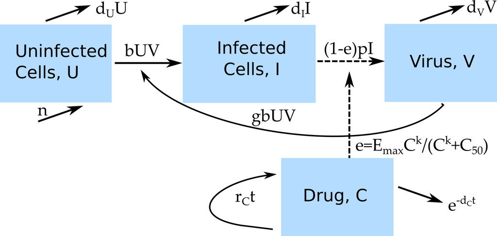

Flow diagram for a virus infection model with drug treatment and Pk-Pd.

### Model Equations

Implementing this model as a continuous-time, deterministic model leads to the following set of ordinary differential equations.

$$\dot U = n - d_U U - bUV$$
$$\dot I = bUV - d_I I$$
$$\dot V = (1-e)pI - d_V V - gb UV$$
$$e = E_{max} \frac{C^k}{C^k+C_{50}}$$
$$C = r_C t_n e^{-d_C t_n}$$
Where *t<sub>n</sub>* is the time since the last dose was given. Prior to treatment start, i.e. (t<txstart), there is no drug and *C=0*.